# exercises

# Ex. 3.9 (using the QR decomposition for fast forward-stepwise selection)

Forward stepwise regression. Suppose we have the $QR$ decomposition for the $N\times q$ matrix $X_1$ in a multiple regression problem with response $y$, and we have an additional $p−q$ predictors in the matrix $X_2$. Denote the current residual by $r$. We wish to establish which one of these additional variables will reduce the residual-sum-of squares the most when included with those in $X_1$. Describe an efficient procedure for doing this.

Since
$$\underset{N\times q}{X_1}=\underset{N\times N}{Q}\underset{N\times q}{R}$$
, If $N\ge q$,
$$\underset{N\times q}{X_1}=\underset{N\times N}{Q}\underset{N\times q}{R}=\begin{bmatrix}
\underset{N\times q}{Q_1} & \underset{N\times (N-q)}{Q_2}
\end{bmatrix}\begin{bmatrix}
\underset{q\times N}{R_1} \\
\underset{(N-q)\times N}{\mathbf 0}
\end{bmatrix}=\begin{bmatrix}
\underset{N\times q}{Q_1} & \underset{N\times (N-q)}{Q_2}
\end{bmatrix}\begin{bmatrix}
\underset{q\times q}{R_2} & \underset{q\times (N-q)}{\mathbf 0}\\
\underset{(N-q)\times q}{\mathbf 0} & \underset{(N-q)\times (N-q)}{\mathbf 0}\\
\end{bmatrix}$$
where $Q_1$ and $Q_2$ both have orthogonal columns. Each column of $X_1$ is
$$x_j=Qr_j$$
.
$$\hat{y}=X_1(X_1^TX_1)^{-1}X_1^Ty=QR(R^TQ^TQR)^{-1}R^TQ^Ty\\
=Q_1R_2R_2^{-1}R_2^{-T}R_2^TQ_1^Ty=Q_1Q_1^Ty$$
Let the $i$-th column is $Q$ is $q_i,\quad (1\le i\le q)$, then $(q_1,\cdots,q_q)$ is an orthonormal basis of $Q$ or $Q_1$, then the best estimator is
$$\underset{i}{\text{argmax }}(q_i^Ty)q_i$$

# Ex. 3.10 (using the z-scores for fast backwards stepwise regression)

Backward stepwise regression. Suppose we have the multiple regression fit of $y$ on $X$, along with the standard errors and Z-scores as in Table 3.2. We wish to establish which variable, when dropped, will increase the residual sum-of-squares the least. How would you do this?

The F statistic,
$$F_{p_1−p_0,N−p_1−1}=\frac{\left(\text{RSS}_0-\text{RSS}_1\right)/\left(p_1-p_0\right)}{\text{RSS}_1/\left(N-p_1-1\right)}$$
where $\text{RSS}_1$ is the residual sum-of-squares for the least squares fit of the bigger model with $p_1+1$ parameters, and $\text{RSS}_0$ the same for the nested smaller model with $p_0+1$ parameters, having $p_1−p_0$ parameters constrained to be zero. The $F$ statistic measures the change in residual sum-of-squares per additional parameter in the bigger model, and it is normalized by an estimate of $\sigma^2$. Under the Gaussian assumptions, and the null hypothesis that the smaller model is correct, the $F$ statistic will have a $F_{p_1−p_0,N−p_1−1}$ distribution.

The $Z-score$
$$z_j=\frac{\hat{\beta}_j}{\hat{\sigma}\sqrt{v_{jj}}}$$
where $v_{jj}$ is the $j$th diagonal element of $(\mathbf X^T\mathbf X)^{−1}$. Under the null hypothesis that $\beta_j = 0$, $z_j$ is distributed as $t_{N−p−1}$ (a $t$ distribution with $N − p − 1$ degrees of freedom), and hence a large (absolute) value of $z_j$ will lead to rejection of this null hypothesis.

Since once $\beta$ is estimated we can compute $\sigma^2$:
$$\hat{\sigma}^2=\frac{1}{N-p-1}\sum_{i=1}^{N}(y_i-\hat{y}_i)^2=\frac{1}{N-p-1}\sum_{i=1}^{N}(y_i-x_i^T\beta)^2=\frac{\text{RSS}_1}{N-p-1}$$
In addition, by just deleting one variable from our regression the difference in degrees of freedom between the two models is one i.e. $p_1 − p_0 = 1$. Thus the $F$-statistic when we delete the $j$th term from the base model simplifies to
$$F_{1,N−p_1−1}=\frac{\left(\text{RSS}_j-\text{RSS}_1\right)}{\text{RSS}_1/\left(N-p_1-1\right)}=\frac{\left(\text{RSS}_j-\text{RSS}_1\right)}{\hat{\sigma}^2}$$

Since
$$\text{RSS}_j-\text{RSS}_1=\left(\mathbf{y'}-\mathbf{X'}\left(\mathbf{X'}^T\mathbf{X'}\right)^{-1}\mathbf{X'}^T\mathbf{y'}\right)^T\left(\mathbf{y'}-\mathbf{X'}\left(\mathbf{X'}^T\mathbf{X'}\right)^{-1}\mathbf{X'}^T\mathbf{y'}\right)-\left(\mathbf{y}-\mathbf{X}\left(\mathbf{X}^T\mathbf{X}\right)^{-1}\mathbf{X}^T\mathbf{y}\right)^T\left(\mathbf{y}-\mathbf{X}\left(\mathbf{X}^T\mathbf{X}\right)^{-1}\mathbf{X}^T\mathbf{y}\right)$$
Where $\mathbf{X'}$ is $\mathbf{X}$ with $j$th column deleted and $\mathbf{y'}$ is $\mathbf{y}$ with $j$th element deleted.

Since that $X^TX(X^TX)^{−1} = I_{p+1}$. Let $u_j$ be the $jth$ column of $X(X^TX)^{−1}$. Using the $v_{ij}$ notation to denote the elements of the matrix $(X^TX)^{−1}$ established above, we have
$$u_j=\sum_{r=1}^{p+1}x_rv_{rj}$$
and
$$\lVert u_j\rVert^2=u_j^Tu_j=\sum_{r=1}^{p+1}v_{rj}x_r^Tu_j=\sum_{r=1}^{p+1}v_{rj}x_r^Tu_j=v_{jj}$$
Then
$$\lVert z_j\rVert^2=\frac{\lVert u_j\rVert^2}{v_{jj}^2}=\frac{1}{v_{jj}}$$
Now
$$\frac{z_j}{\lVert z_j\rVert}$$
is a unit vector orthogonal to $x_1, \cdots , x_{j−1}, x_{j+1}, \cdots , x_{p+1}$. So
$$\text{RSS}_j-\text{RSS}_1=\left<y,\frac{z_j}{\lVert z_j\rVert}\right>^2=\left(\frac{<y,z_j>}{<z_j,z_j>}\right)^2\lVert z_j\rVert^2=\hat{\beta}_j^2/v_{jj}$$
and
$$F_{1,N−p_1−1}=\frac{\left(\text{RSS}_j-\text{RSS}_1\right)}{\text{RSS}_1/\left(N-p_1-1\right)}=\frac{\left(\text{RSS}_j-\text{RSS}_1\right)}{\hat{\sigma}^2}=\frac{\hat{\beta}_j^2}{\hat{\sigma}^2v_{jj}}=z_j^2$$

# Ex. 3.11 (multivariate linear regression with different $\Sigma_i$)

Show that the solution to the multivariate linear regression problem (3.40) is given by (3.39). What happens if the covariance matrices $\mathbf\Sigma_i$ are different for each observation?

$$\begin{align}
\text{RSS}(\mathbf{B}) &= \sum_{k=1}^K \sum_{i=1}^N \left( y_{ik} - f_k(x_i) \right)^2 \\
&= \text{trace}\left( (\mathbf{Y}-\mathbf{XB})^T(\mathbf{Y}-\mathbf{XB}) \right)
\end{align}\quad(Equation\;\;3.38)$$
$$\begin{equation}
\hat{\mathbf{B}} = \left(\mathbf{X}^T\mathbf{X}\right)^{-1}\mathbf{X}^T\mathbf{Y}.
\end{equation}\quad(Equation\;\;3.39)$$
$$\begin{equation}
\text{RSS}(\mathbf{B};\mathbf{\Sigma}) = \sum_{i=1}^N (y_i-f(x_i))^T \mathbf{\Sigma}^{-1} (y_i-f(x_i))
\end{equation} \quad(Equation\;\;3.40)$$

With $N$ training cases we can write the model in matrix notation
$$\begin{equation}
\mathbf{Y}=\mathbf{XB}+\mathbf{E},
\end{equation}$$
where

- $\mathbf{Y}$ is $N\times K$ with $ik$ entry $y_{ik}$,
- $\mathbf{X}$ is $N\times(p+1)$ input matrix,
- $\mathbf{B}$ is $(p+1)\times K$ parameter matrix,
- $\mathbf{E}$ is $N\times K$ error matrix.

A straightforward generalization of the univariate loss function is
$$\begin{align}
\text{RSS}(\mathbf{B}) &= \sum_{k=1}^K \sum_{i=1}^N \left( y_{ik} - f_k(x_i) \right)^2 \\
&= \text{trace}\left( (\mathbf{Y}-\mathbf{XB})^T(\mathbf{Y}-\mathbf{XB}) \right)
\end{align}$$

The least squares estimates have exactly the same form as before
$$\begin{equation}
\hat{\mathbf{B}} = \left(\mathbf{X}^T\mathbf{X}\right)^{-1}\mathbf{X}^T\mathbf{Y}.
\end{equation} \quad(Equation\;\;3.39)$$

If the errors $\epsilon = (\epsilon_1,\cdots,\epsilon_K)$ are correlated with $\text{Cov}(\epsilon)=\mathbf{\Sigma}$, then the multivariate weighted criterion
$$\begin{equation}
\text{RSS}(\mathbf{B};\mathbf{\Sigma}) = \sum_{i=1}^N (y_i-f(x_i))^T \mathbf{\Sigma}^{-1} (y_i-f(x_i))
\end{equation} \quad(Equation\;\;3.40)$$

if the covariance matrices $\mathbf\Sigma_i$ are different for each observation
$$\begin{equation}
\text{RSS}(\mathbf{B}) = \sum_{i=1}^N (y_i-f(x_i))^T \mathbf{\Sigma_i}^{-1} (y_i-f(x_i))
\end{equation}$$

# Ex. 3.12 (ordinary least squares to implement ridge regression)

Show that the ridge regression estimates can be obtained by ordinary least squares regression on an augmented data set. We augment the centered matrix $X$ with $p$ additional rows $\sqrt{\lambda}\mathbf I$, and augment $y$ with $p$ zeros. By introducing artificial data having response value zero, the fitting procedure is forced to shrink the coefficients toward zero. This is related to the idea of hints due to Abu-Mostafa (1995), where model constraints are implemented by adding artificial data examples that satisfy them.

Consider the input centered data matrix $\mathbf X$ (of size $p\times p$) and the output data vector $\mathbf Y$ both appended (to produce the new variables $\hat{\mathbf X}$ and $\hat{\mathbf Y}$ ) as follows
$$\hat{\mathbf X}=\begin{bmatrix}
\underset{p\times p}{\mathbf X}\\
\sqrt{\lambda}\underset{p\times p}{\mathbf I}\\
\end{bmatrix}$$
and
$$\hat{\mathbf Y}=\begin{bmatrix}
\underset{p\times 1}{\mathbf Y}\\
\underset{p\times 1}{\mathbf 0}\\
\end{bmatrix}$$
The the classic least squares solution to this new problem is given by
$$\begin{align}
\hat{\mathbf{\beta^{ls}}} &= \left(\mathbf{\hat X}^T\mathbf{\hat X}\right)^{-1}\mathbf{\hat X}^T\mathbf{\hat Y}\\
&=\left(\begin{bmatrix}
\underset{p\times p}{\mathbf X}^T&\sqrt{\lambda}\underset{p\times p}{\mathbf I}^T\\
\end{bmatrix}\begin{bmatrix}
\underset{p\times p}{\mathbf X}\\
\sqrt{\lambda}\underset{p\times p}{\mathbf I}\\
\end{bmatrix}\right)^{-1}\begin{bmatrix}
\underset{p\times p}{\mathbf X}^T&\sqrt{\lambda}\underset{p\times p}{\mathbf I}^T\\
\end{bmatrix}\begin{bmatrix}
\underset{p\times 1}{\mathbf Y}\\
\underset{p\times 1}{\mathbf 0}\\
\end{bmatrix}\\
&=\left(\mathbf X^T\mathbf X+\lambda\mathbf I\right)^{-1}\left(\mathbf X^T\mathbf Y\right)
\end{align}$$
This expression we recognize as the solution to the regularized least squares proving the equivalence.

# Ex. 3.13 (principal component regression)

Derive the expression (3.62), and show that
$$\hat{\beta}^{pcr}(p)=\hat{β}^{ls}$$

The linear combinations $Z_m$ used in principal component regression (PCR) are the principal components. PCR forms the derived input columns
$$\begin{equation}
\mathbf{z}_m = \mathbf{X} v_m,
\end{equation}$$
and then regress $\mathbf{y}$ on $\mathbf{z}_1,\mathbf{z}_2,\cdots,\mathbf{z}_M$ for some $M\le p$. Since the $\mathbf{z}_m$ are orthogonal, this regression is just a sum of univariate regressions:
$$\begin{equation}
\hat{\mathbf{y}}_{(M)}^{\text{pcr}} = \bar{y}\mathbf{1} + \sum_{m=1}^M \hat\theta_m \mathbf{z}_m = \bar{y}\mathbf{1} + \mathbf{X}\mathbf{V}_M\hat{\mathbf{\theta}}=\bar{y}\mathbf{1} + \mathbf{X}\sum_{m=1}^M\hat\theta_mv_m,
\end{equation}$$

where $\hat\theta_m = \langle\mathbf{z}_m,\mathbf{y}\rangle \big/ \langle\mathbf{z}_m,\mathbf{z}_m\rangle$. We can see from the last equality that, since the $\mathbf{z}_m$ are each linear combinations of the original $\mathbf{x}_j$, we can express the solution in terms of coefficients of the $\mathbf{x}_j$.
$$\begin{bmatrix}
\mathbf 1 &\mathbf X
\end{bmatrix}$$
and
$$\begin{equation}
\hat\beta^{\text{pcr}}(M) = \begin{bmatrix}
\bar{y}\\
\sum_{m=1}^M \hat\theta_m v_m
\end{bmatrix}
\end{equation} \quad(Equation\;\;3.62)$$

For multiple linear regression models the estimated regression coefficients in the vector $\hat{\beta}$ can be split into two parts a scalar $\hat\beta_0$ and a $p \times 1$ vector $\hat\beta^∗$ as
$$\hat{\beta}=\begin{bmatrix}
\hat\beta_0\\
\hat\beta^∗
\end{bmatrix}$$
In addition the coefficient $\hat\beta_0$ can be shown to be related to $\hat\beta^∗$ as
$$\hat\beta_0=\bar{y}-\hat\beta^∗\bar{x}$$
and since
$$\begin{bmatrix}
\bar{y}\\
\sum_{m=1}^M \hat\theta_m v_m
\end{bmatrix}=\begin{bmatrix}
\hat\beta_0\\
\hat\beta^∗
\end{bmatrix}$$
then $\hat\beta_0=\bar{y}$ and $\bar{x}=0$, which means in in principal component regression, the input predictor variables are standardized.

To evaluate $\hat\beta^{\text{pcr}}(M)$ when $M = p$, recall that in principal component regression the vectors $v_m$ are from the $SVD$ decomposition of the matrix $X$ given by $X = UDV^T$. This later expression is equivalent to $XV = UD$ from which we get
$$\begin{align}
Xv_1&=d_1u_1\\
Xv_2&=d_2u_2\\
\vdots\\
Xv_p&=d_pu_p\\
\end{align}$$
Since the vectors $z_m$ are given by $z_m = Xv_m$ for $1 \le m \le M \le p$, by the above we have the vectors $z_m$ in terms of the vectors $u_m$ as $z_m = d_mu_m$. Since for this problem we are to show that when $M = p$ the estimate $\hat\beta^{\text{pcr}}(M)$ above becomes the least squares estimate $\hat\beta^{\text{ls}}$ When $\lambda = 0$ the ridge regression estimate for $\beta$ is equal to the least squares estimate (when $\lambda = 0$ we have no $\lambda\lVert\beta\rVert_2^2$ ridge penalty term) we can use Equation
$$\begin{align}
\hat\beta^{\text{ridge}} &= \left( \mathbf{X}^T\mathbf{X} + \lambda\mathbf{I} \right)^{-1}\mathbf{X}^T\mathbf{y}\\
&=(\mathbf V\mathbf D^2\mathbf V^T+\lambda\mathbf{V}\mathbf{V}^T)^{-1}\mathbf V\mathbf D\mathbf U^T\mathbf{y}\\
&=(\mathbf V(\mathbf D^2+\lambda\mathbf{I})\mathbf{V}^T)^{-1}\mathbf V\mathbf D\mathbf U^T\mathbf{y}\\
&=\mathbf{V}^{-T}(\mathbf D^2+\lambda\mathbf{I})^{-1}\mathbf D\mathbf U^T\mathbf{y}\\
&=\mathbf{V}(\mathbf D^2+\lambda\mathbf{I})^{-1}\mathbf D\mathbf U^T\mathbf{y}\\
\end{align}$$
to obtain
$$\hat\beta^{\text{ls}}=\hat\beta^{\text{ridge}}(\lambda=0)=\mathbf{V}\mathbf D^{-2}\mathbf D\mathbf U^T\mathbf{y}\\=\mathbf{V}\mathbf D^{-1}\mathbf U^T\mathbf{y}$$
Since
$$\hat\beta^{\text{pcr}}(p)=\sum_{m=1}^M\hat\theta_mv_m=\mathbf{V}\begin{bmatrix}
\hat\theta_1\\
\hat\theta_2\\
\vdots\\
\hat\theta_p
\end{bmatrix}=\mathbf{V}\begin{bmatrix}
\langle\mathbf{z}_1,\mathbf{y}\rangle \big/ \langle\mathbf{z}_1,\mathbf{z}_1\rangle\\
\langle\mathbf{z}_2,\mathbf{y}\rangle \big/ \langle\mathbf{z}_2,\mathbf{z}_2\rangle\\
\vdots\\
\langle\mathbf{z}_p,\mathbf{y}\rangle \big/ \langle\mathbf{z}_p,\mathbf{z}_p\rangle
\end{bmatrix}$$
and since $z_m = d_mu_m$ we have
$$\langle\mathbf{z}_m,\mathbf{z}_m\rangle=d_m^2\langle\mathbf{u}_m,\mathbf{u}_m\rangle=d_m^2$$
since the vectors $u_m$ are assumed to be orthonormal. Also $\langle\mathbf{z}_m,\mathbf{y}\rangle = d_m \langle\mathbf{u}_m,\mathbf{y}\rangle$, so the estimate for
$$\hat\beta^{\text{pcr}}(p)=\mathbf{V}\begin{bmatrix}
\langle\mathbf{z}_1,\mathbf{y}\rangle \big/ \langle\mathbf{z}_1,\mathbf{z}_1\rangle\\
\langle\mathbf{z}_2,\mathbf{y}\rangle \big/ \langle\mathbf{z}_2,\mathbf{z}_2\rangle\\
\vdots\\
\langle\mathbf{z}_p,\mathbf{y}\rangle \big/ \langle\mathbf{z}_p,\mathbf{z}_p\rangle
\end{bmatrix}=\mathbf{V}\begin{bmatrix}
\langle\mathbf{u}_1,\mathbf{y}\rangle \big/ d_1\\
\langle\mathbf{u}_1,\mathbf{y}\rangle \big/ d_1\\
\vdots\\
\langle\mathbf{u}_1,\mathbf{y}\rangle \big/ d_1\\
\end{bmatrix}=\mathbf{V}\mathbf D^{-1}\mathbf U^T\mathbf{y}\\
=\hat\beta^{\text{ls}}=\hat\beta^{\text{ridge}}(\lambda=0)$$

# Ex. 3.14 (when the inputs are orthogonal PLS stops after m = 1 step)

Show that in the orthogonal case, $\text{PLS}$ stops after $m = 1$ steps, because subsequent $\hat{\varphi}_{mj}$ in step 2 in Algorithm 3.3 are zero.

Algorithm 3.3 Partial Least Squares:

1. Standardize each $x_j$ to have mean zero and variance one. Set $\hat y^{(0)} =\bar{y}\mathbf 1$, and $x^{(0)}_j = x_j , j = 1, \cdots, p$.
2. For $m=1,2,\cdots,p$
1. $$z_m=\sum_{j=1}^{p}\hat\varphi_{mj}x_j^{(m-1)}$$
   where
   $$\hat\varphi_{mj}=\langle x_j^{(m-1)}, y\rangle$$
2. $$\hat\theta_m=\langle z_m, y\rangle\big/\langle z_m, z_m\rangle$$
3. $$\hat{y}^{(m)}=\hat{y}^{(m-1)}+\hat\theta_mz_m$$
4. Orthogonalize each $x_j^{(m-1)}$ with respect to
   $$z_m:x_j^{(m)}=x_j^{(m-1)}-\left[\langle z_m, x_j^{(m-1)}\rangle\big/\langle z_m, z_m\rangle\right]z_m, j=1,2,\cdots,p$$
3. Output the sequence of fitted vectors $\{\hat y^{(m)}\}_1^p$. Since the $\{z_{\ell}\}_1^m$ are linear in the original $x_j$, so is $\hat y^{(m)} = X\hat{\beta}^{\text{pls}}(m)$. These linear coefficients can be recovered from the sequence of $\text{PLS}$ transformations.

In Algorithm 3.3 on partial least squares (PLS) if on any given step $m$ we compute that
$$\hat\varphi_{mj} =\langle x_j^{(m-1)}, y\rangle= 0$$
for all $j$ then all
$$z_m=\sum_{j=1}^{p}\hat\varphi_{mj}x_j^{(m-1)}=0$$
it follows that the algorithm must stop. If the $x_j$’s are orthogonal, we have

1. $$z_1=\sum_{j=1}^{p}\hat\varphi_{1j}x_j^{(0)}$$
   where
   $$\hat\varphi_{1j}=\langle x_j^{(0)}, y\rangle$$
2. $$\hat\theta_1=\langle z_1, y\rangle\big/\langle z_1, z_1\rangle$$
   Since
   $$\begin{align}
   \langle z_1, z_1\rangle&=\left\langle \sum_{j=1}^{p}\hat\varphi_{1j}x_j^{(0)}, \sum_{j=1}^{p}\hat\varphi_{1j}x_j^{(0)}\right\rangle\\
   &=\sum_{j=1}^{p}\sum_{j'=1}^{p}\hat\varphi_{1j}\hat\varphi_{1j'}\left\langle x_j^{(0)},x_{j'}^{(0)}\right\rangle\\
   &=\sum_{j=1}^{p}\hat\varphi_{1j}^2\\
   \end{align}$$
   since the vectors $x_j^{(0)}$ are orthogonal.
   $$\langle z_1, y\rangle=\left\langle \sum_{j=1}^{p}\hat\varphi_{1j}x_j^{(0)}, y\right\rangle=\sum_{j=1}^{p}\hat\varphi_{1j}\left\langle x_j^{(0)}, y\right\rangle=\sum_{j=1}^{p}\hat\varphi_{1j}^2$$
   and thus we have
   $$\hat\theta_1=\langle z_1, y\rangle\big/\langle z_1, z_1\rangle=1$$
3. $$\hat{y}^{(1)}=\hat{y}^{(0)}+\hat\theta_1z_1=\hat{y}^{(0)}+z_1=\hat{y}^{(0)}+\sum_{j=1}^{p}\hat\varphi_{1j}x_j^{(0)}$$
4. Orthogonalize each $x_j^{(1)}, j=1,2,\cdots,p$ with respect to
   $$z_1:x_j^{(1)}=x_j^{(0)}-\left[\langle z_1, x_j^{(0)}\rangle\big/\langle z_1, z_1\rangle\right]z_1$$
   Since the vectors $x^{(0)}_j$ are orthogonal
   $$\langle z_1, x_k^{(0)}\rangle=\sum_{j=1}^{p}\hat\varphi_{1j}\langle x_j^{(0)}, x_k^{(0)}\rangle=\hat\varphi_{1k}$$
   then
   $$\begin{align}
   x_j^{(1)}&=x_j^{(0)}-\left[\langle z_1, x_j^{(0)}\rangle\big/\langle z_1, z_1\rangle\right]z_1\\
   &=x_j^{(0)}-\left[\hat\varphi_{1j}\big/\sum_{j=1}^{p}\hat\varphi_{1j}^2\right]\sum_{j=1}^{p}\hat\varphi_{1j}x_j^{(0)}\\
   \end{align}$$
   Having finished the first loop of Algorithm 3.3 we let $m = 2$ and compute $\hat\varphi_{2j}$ to get
   $$\hat\varphi_{2j}=\langle x_j^{(1)}, y\rangle=\langle x_j^{(0)}, y\rangle-\left[\hat\varphi_{1j}\big/\sum_{j=1}^{p}\hat\varphi_{1j}^2\right]\sum_{j=1}^{p}\hat\varphi_{1j}^2\\
   =\hat\varphi_{1j}-\hat\varphi_{1j}=0$$

# Ex. 3.15 (PLS seeks directions that have high variance and high correlation)

Verify expression (3.64), and hence show that the partial least squares directions are a compromise between the ordinary regression coefficient and the principal component directions.

PLS begins by computing the weights
$$\begin{equation}
\hat\varphi_{1j} = \langle \mathbf{x}_j,\mathbf{y} \rangle, \text{ for each } j,
\end{equation}$$
which are in fact the univariate regression coefficients, since $\mathbf{x}_j$ are standardized (only for the first step $m=1$).

From this we construct derived input
$$\begin{equation}
\mathbf{z}_1 = \sum_j \hat\varphi_{1j}\mathbf{x}_j,
\end{equation}$$
which is the first PLS direction. Hence in the construction of each $\mathbf{z}_m$, the inputs are weighted by the strength of their univariate effect on $\mathbf{y}$.

The outcome $\mathbf{y}$ is regressed on $\mathbf{z}_1$ giving coefficient $\hat\theta_1$, and then we orthogonalize $\mathbf{x}_1,\cdots,\mathbf{x}_p$ w.r.t. $\mathbf{z}_1$.

We continue this process, until $M\le p$ directions have been obtained. In this manner, PLS produces a sequence of derived, orthogonal inputs or directions $\mathbf{z}_1,\cdots,\mathbf{z}_M$.

- As with PCR, if $M=p$, then $\hat\beta^{\text{pls}} = \hat\beta^{\text{ls}}$.
- Using $M<p$ directions produces a reduced regression.

### Relation to the optimization problem

> PLS seeks direction that have high variance *and* have high correlation with the response, in contrast to PCR with keys only on high variance (Stone and Brooks, 1990; Frank and Friedman, 1993). Since it uses the response $\mathbf{y}$ to construct its directions, its solution path is a nonlinear function of $\mathbf{y}$.

In particular, the $m$th principal component direction $v_m$ solves:
$$\begin{equation}
\max_\alpha \text{Var}(\mathbf{X}\alpha)\\
\text{subject to } \|\alpha\| = 1, \alpha^T\mathbf{S} v_l = 0 \text{ for } l = 1,\cdots, m-1,
\end{equation}$$
where $\mathbf{S}$ is the sample covariance matrix of the $\mathbf{x}_j$. The condition $\alpha^T\mathbf{S} v_l= 0$ ensures that $\mathbf{z}_m = \mathbf{X}\alpha$ is uncorrelated with all the previous linear combinations $\mathbf{z}_l = \mathbf{X} v_l$.

The $m$th PLS direction $\hat\varphi_m$ solves:
$$\begin{equation}
\max_\alpha \text{Corr}^2(\mathbf{y},\mathbf{S}\alpha)\text{Var}(\mathbf{X}\alpha)\\
\text{subject to } \|\alpha\| = 1, \alpha^T\mathbf{S}\hat\varphi_l = 0, \text{ for } l=1,\cdots, m-1.
\end{equation} \quad (3.64)$$

# Ex. 3.16 (explicit expressions for $\hat\beta_j$ when the features are orthonormal)

Derive the entries in Table 3.4, the explicit forms for estimators in the orthogonal case.

$$\begin{array}{l}
\text{Estimator} & \text{Formula}\\
\hline
\text{Best subset (size M)} &\hat{\beta}_j\cdot I(\lvert\hat{\beta}_j\rvert\ge\lvert\hat{\beta}_{(M)}\rvert)\\
\text{Ridge} & \hat{\beta}_j\big/(1+\lambda)\\
\text{Lasso} & \text{sign}(\hat{\beta}_j)(\lvert\hat{\beta}_j\rvert-\lambda)_+\\
\hline
\end{array}$$
When the predictors are orthonormal $X^TX = I$ and the ordinary least squared estimate of $\beta$ is given by
$$\hat\beta=X^TY$$

In best-subset selection we will take the top $M$ predictors that result in the smallest residual sum of squares. Since the columns of $X$ are orthonormal we can construct a basis for $\mathbb R^N$ by using the first $p$ columns of $X$ and then extending these with $N −p$ linearly independent additional orthonormal vectors. The Gram-Schmidt procedure guarantees that we can do this. Thus in this extended basis we can write $y$ as
$$y=\sum_{j=1}^{p}\hat\beta_jx_j+\sum_{j=p+1}^{N}\gamma_j\tilde{x}_j$$
where $\hat\beta_j$ equal the components of $\hat\beta$ in
$$\hat\beta=X^TY$$
$\tilde{x}_j$ are the extended basis vectors required to span $\mathbb R^N$, and $\gamma_j$ are the coefficients of $y$ with respect to these extended basis vectors. Then if we seek to approximate $y$ with a subset of size $M$ as in best subset selection, $\hat y$ can be written as
$$\hat y=\sum_{j=1}^{p}I_j\hat\beta_jx_j$$
with $I_j=1$ if we keep the predictor $x_j$ and zero otherwise. Now since all the vectors $x_j$ and $\tilde{x}_j$ are orthonormal we have
$$\begin{align}
\lVert y-\hat y\rVert_2^2&=\lVert y-X\hat\beta\rVert_2^2\\
&=\left\lVert \sum_{j=1}^{p}\hat\beta_jx_j+\sum_{j=p+1}^{N}\gamma_j\tilde{x}_j-X\hat\beta\right\rVert_2^2\\
&=\left\lVert \sum_{j=1}^{p}\hat\beta_j(\mathbf 1-I_j)x_j+\sum_{j=p+1}^{N}\gamma_j\tilde{x}_j\right\rVert_2^2\\
&=\sum_{j=1}^{p}\hat\beta_j^2(\mathbf 1-I_j)^2\left\lVert x_j\right\rVert_2^2+\sum_{j=p+1}^{N}\gamma_j^2\left\lVert\tilde{x}_j\right\rVert_2^2\\
&=\sum_{j=1}^{p}\hat\beta_j^2(\mathbf 1-I_j)^2+\sum_{j=p+1}^{N}\gamma_j^2\\
\end{align}$$

Thus to minimize $\lVert y-\hat y\rVert_2^2$ we would pick the $M$ values of $I_j$ to be equal to one that have the largest $\beta_j^2$ values. This is equivalent to sorting the values $\lvert\hat\beta_j\rvert$ and picking the indices of the largest $M$ of these to have $I_j = 1$. All other indices $j$ would be taken to have $I_j = 0$. Using an indicator function this is equivalent to the expression
$$\hat\beta_j^{\text{best subset}}=\hat\beta_j\cdot I\left( \lvert\hat\beta_j\rvert \ge \lvert\hat\beta_{(M)}\rvert \right)$$

- Best subset (size $M$) drops all variables with coefficients smaller than the $M$th largest; this is a form of “hard-thresholding”.

$$\begin{equation}
\hat\beta_j\cdot I\left( \lvert\hat\beta_j\rvert \ge \lvert\hat\beta_{(M)}\rvert \right)
\end{equation}$$

For ridge regression, since $X$ has orthonormal columns we have
$$\begin{align}
\hat\beta^{\text{ridge}}&= \left( \mathbf{X}^T\mathbf{X} + \lambda I \right)^{-1}\mathbf{X}^T\mathbf{y}\\
&=\left( I + \lambda I \right)^{-1}\mathbf{X}^T\mathbf{y}\\
&=\frac{\mathbf{X}^T\mathbf{y}}{1+\lambda}\\
&=\frac{\hat\beta^{\text{ls}}}{1+\lambda}
\end{align}$$
* Ridge does a proportional shrinkage.

$$\begin{equation}
\frac{\hat\beta_j}{1+\lambda}
\end{equation}$$

The lasso estimate is defined by
$$\begin{equation}
\hat\beta^{\text{lasso}} = \arg\min_\beta \left\lbrace \frac{1}{2}\sum_{i=1}^N \left( y_i-\beta_0-\sum_{j=1}^p x_{ij}\beta_j \right)^2 + \lambda\sum_{j=1}^p |\beta_j| \right\rbrace,
\end{equation}$$
For the lasso regression procedure we pick the values of $\beta_j$ to minimize
$$\text{RSS}(\beta)=\frac{1}{2}(y-X\beta)^T(y-X\beta)+\lambda\sum_{j=1}^{p}\lvert \beta_j\rvert$$
Expanding $\hat y$ as
$$\hat y = \sum_{j=1}^{p} \beta_jx_j$$
and with
$$y=\sum_{j=1}^{p}\hat\beta_jx_j+\sum_{j=p+1}^{N}\gamma_j\tilde{x}_j$$
we have that $\text{RSS}(\beta)$ in this case becomes
$$\begin{align}
\text{RSS}(\beta)&=\frac{1}{2}\left\lVert \sum_{j=1}^{p}(\hat\beta_j-\beta_j)x_j+\sum_{j=p+1}^{N}\gamma_j\tilde{x}_j\right\rVert_2^2+\lambda\sum_{j=1}^{p}\lvert \beta_j\rvert\\
&=\frac{1}{2}\sum_{j=1}^{p}(\hat\beta_j-\beta_j)^2+\frac{1}{2}\sum_{j=p+1}^{N}\gamma_j^2+\lambda\sum_{j=1}^{p}\lvert \beta_j\rvert\\
&=\frac{1}{2}\sum_{j=1}^{p}\left[(\hat\beta_j-\beta_j)^2+2\lambda\lvert \beta_j\rvert\right]+\sum_{j=p+1}^{N}\gamma_j^2
\end{align}$$
We can minimize this expression for each value of $\beta_j$ for $1 \le j \le p$ independently. Thus our vector problem becomes that of solving $p$ scalar minimization problems all of which look like
$$\beta^*=\text{argmin}_{\beta}\left[(\hat\beta-\beta)^2+2\lambda\lvert \beta\rvert\right]$$
Then the objective function we want to minimize is
$$F(\beta)=\begin{cases}
(\hat\beta-\beta)^2-2\lambda\beta &\text{ when } \beta<0\\[2ex]
(\hat\beta-\beta)^2+2\lambda\beta &\text{ when } \beta>0\\
\end{cases}$$
where $\hat\beta$ is the least squares estimate.

To find the minimum of this function take the derivative with respect to $\beta$ and set the result equal to zero and solve for $\beta$. We find the derivative of $F(\beta)$ given by
$$F'(\beta)=\begin{cases}
2(\beta-\hat\beta)-2\lambda &\text{ when } \beta<0\\[2ex]
2(\beta-\hat\beta)+2\lambda &\text{ when } \beta>0\\
\end{cases}$$
When we set $F'(\beta)$ equal to zero we get two possible solutions for $\beta$ given by
$$\begin{cases}
\beta=+\lambda+\hat\beta &\text{ when } \beta<0\\[2ex]
\beta=-\lambda+\hat\beta &\text{ when } \beta>0\\[2ex]
\end{cases}$$

- Lasso translates each coefficient by a constant factor $\lambda$, truncating at zero. This is called “soft-thresholding”.

$$\begin{equation}
\text{sign}\left( \hat\beta_j \right)\left( \lvert\hat\beta_j\rvert - \lambda \right)_+
\end{equation}$$

In this expression $\hat\beta$ and $\lambda$ are assumed fixed.

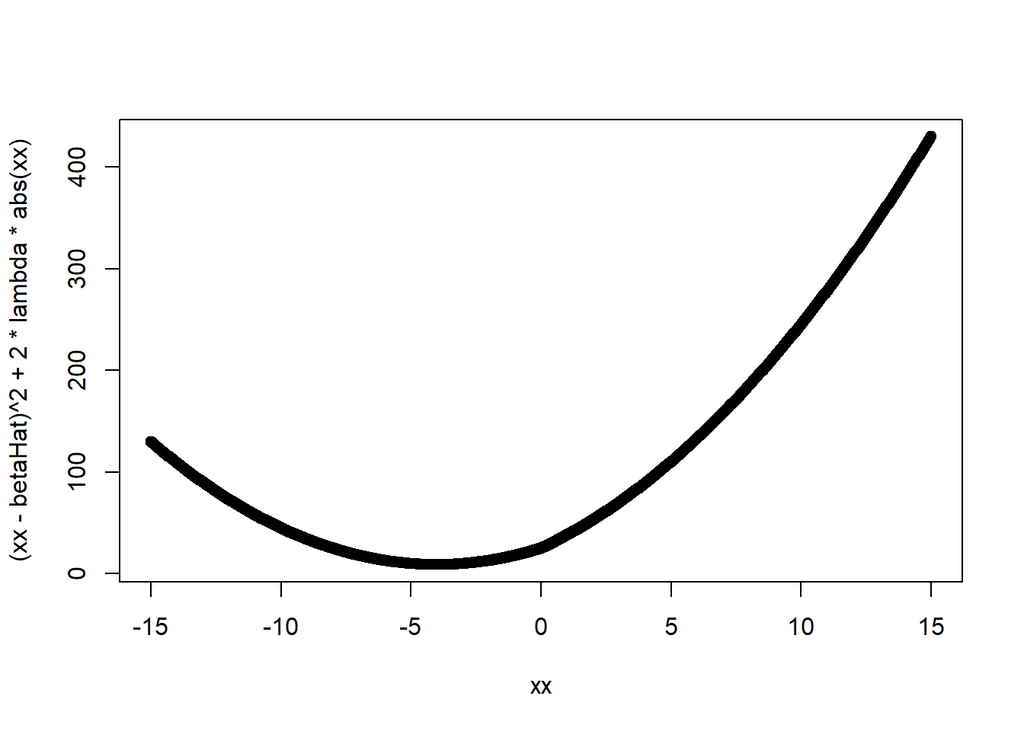

```r
xx = seq(-15,+15,length=1000) # the range of beta's to sample

# the specific parameters:
betaHat = -5.0
lambda  = 1.0

plot( xx, ( xx - betaHat )^2 + 2*lambda*abs(xx) )
```

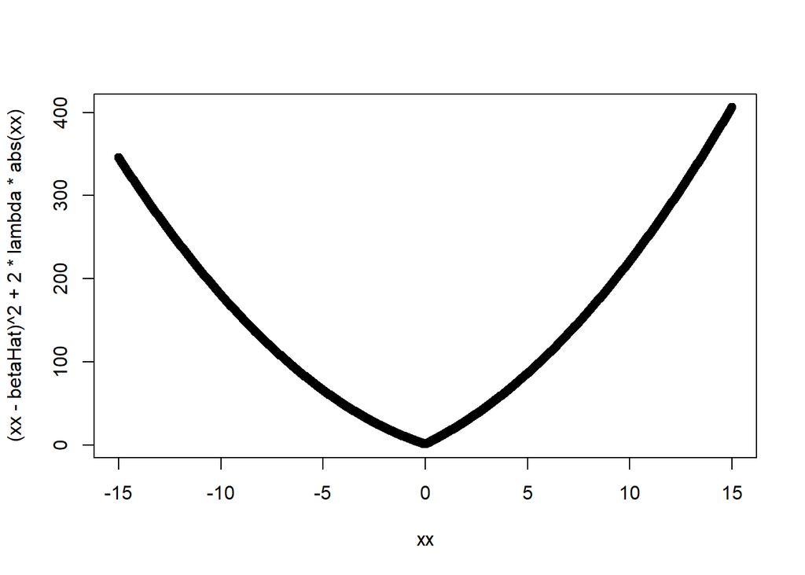

```r
betaHat = -1.0
lambda  = 5.0


plot( xx, ( xx - betaHat )^2 + 2*lambda*abs(xx) )
```

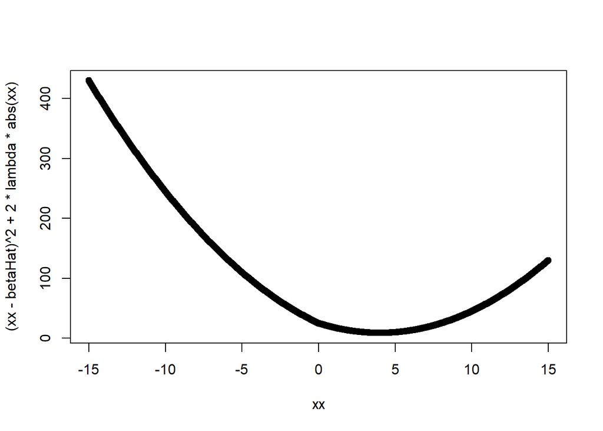

```r
betaHat = 5.0
lambda  = 1.0


plot( xx, ( xx - betaHat )^2 + 2*lambda*abs(xx) )
```

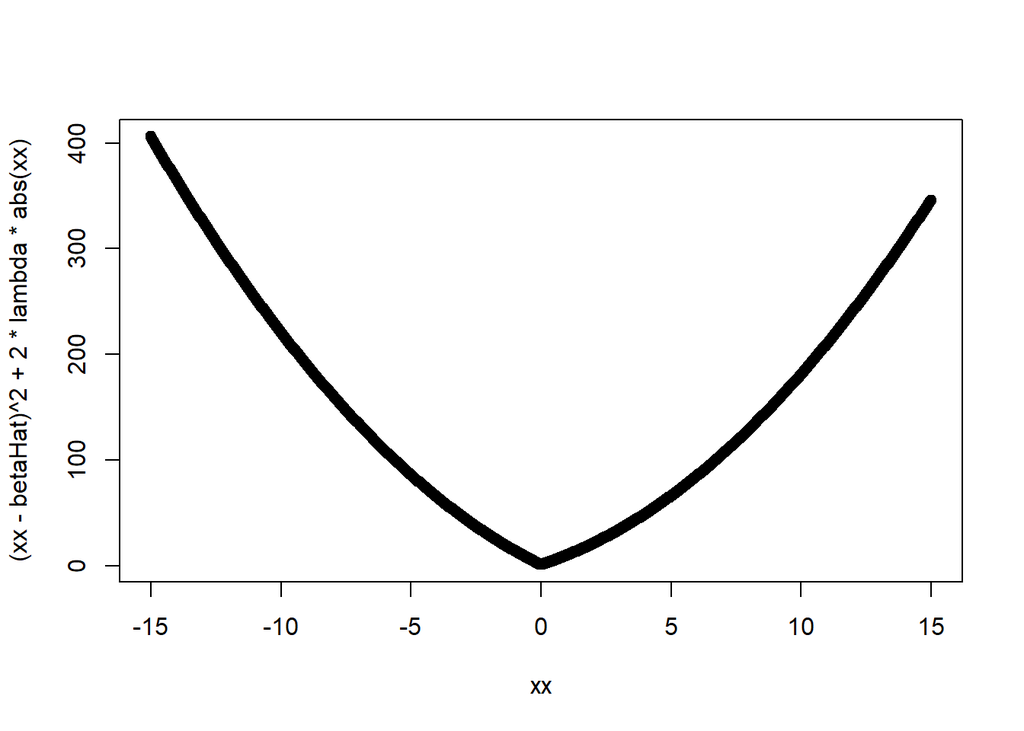

```r
betaHat = 1.0
lambda  = 5.0


plot( xx, ( xx - betaHat )^2 + 2*lambda*abs(xx) )
```

# Ex. 3.17 (linear methods on the spam data set)

Repeat the analysis of Table 3.3 on the spam data discussed in Chapter 1.

load the data:

```r
load_spam_data <- function(trainingScale=TRUE,responseScale=TRUE){

  X      = read.table("../../data/Spam/spam.data.txt")
  tt     = read.table("../../data/Spam/spam.traintest.txt")

  # separate into training/testing sets

  XTraining = subset( X, tt==0 )
  p = dim(XTraining)[2]-1

  XTesting  = subset( X, tt==1 )

  #
  # Sometime data is processed and stored in a certain order.  When doing cross validation
  # on such data sets we don't want to bias our results if we grab the first or the last samples.
  # Thus we randomize the order of the rows in the Training data frame to make sure that each
  # cross validation training/testing set is as random as possible.
  #
  if( FALSE ){
    nSamples = dim(XTraining)[1]
    inds = sample( 1:nSamples, nSamples )
    XTraining = XTraining[inds,]
  }

  #
  # In reality we have to estimate everything based on the training data only
  # Thus here we estimate the predictor statistics using the training set
  # and then scale the testing set by the same statistics
  #
  if( trainingScale ){
    X = XTraining
    if( responseScale ){
      meanV58 = mean(X$V58)
      v58 = X$V58 - meanV58
    }else{
      v58 = X$V58
    }
    X$V58 = NULL
    X = scale(X, TRUE, TRUE)
    means = attr(X,"scaled:center")
    stds = attr(X,"scaled:scale")
    Xf = data.frame(X)
    Xf$V58 = v58
    XTraining = Xf

    # scale the testing predictors by the same amounts:
    #
    DCVTest  = XTesting
    if( responseScale ){
      v58Test = DCVTest$V58 - meanV58
    }else{
      v58Test = DCVTest$V58 # in physical units (not mean adjusted)
    }
    DCVTest$V58 = NULL
    DCVTest  = t( apply( DCVTest, 1, '-', means ) )
    DCVTest  = t( apply( DCVTest, 1, '/', stds ) )
    DCVTestb = cbind( DCVTest, v58Test ) # append back on the response
    DCVTestf = data.frame( DCVTestb ) # a data frame containing all scaled variables of interest
    names(DCVTestf)[p+1] = "V58" # fix the name of the response
    XTesting = DCVTestf
  }

  # Many algorithms wont do well if the data is presented all of one class and
  # then all of another class thus we permute our data frames :
  #
  XTraining = XTraining[sample(nrow(XTraining)),]
  XTesting  = XTesting[sample(nrow(XTesting)),]

  # Read in the list of s(pam)words (and delete garbage characters):
  #
  spam_words = read.table("../../data/Spam/spambase.names",skip=33,sep=":",comment.char="|",stringsAsFactors=F)
  spam_words = spam_words[[1]]
  for( si in 1:length(spam_words) ){
    spam_words[si] = sub( "word_freq_", "", spam_words[si] )
    spam_words[si] = sub( "char_freq_", "", spam_words[si] )
  }

  return( list( XTraining, XTesting, spam_words ) )
}
```

OLS:

```r
res = load_spam_data(trainingScale=TRUE,responseScale=FALSE)
XTraining = res[[1]]
XTesting = res[[2]]

nrow = dim( XTraining )[1]
p = dim( XTraining )[2] - 1 # the last column is the response

D = XTraining[,1:p] # get the predictor data

# Append a column of ones:
#
Dp = cbind( matrix(1,nrow,1), as.matrix( D ) )

response = XTraining[,p+1]

library(MASS)

betaHat = ginv( t(Dp) %*% Dp ) %*% t(Dp) %*% as.matrix(response)

# this is basically the first column in Table 3.2:
#
print('first column: beta estimates')
```

```
## [1] "first column: beta estimates"
```

```r
print(betaHat,digits=2)
```

```
##           [,1]
##  [1,]  0.39739
##  [2,] -0.01206
##  [3,] -0.01819
##  [4,]  0.02442
##  [5,]  0.01778
##  [6,]  0.04832
##  [7,]  0.03509
##  [8,]  0.08263
##  [9,]  0.03889
## [10,]  0.01225
## [11,]  0.01010
## [12,]  0.00834
## [13,] -0.02260
## [14,]  0.00082
```

[output cut: 44 more lines]

```r
# make predictions based on these estimated beta coefficients:
#
yhat = Dp %*% betaHat

# estimate the variance:
#
sigmaHat = sum( ( response - yhat )^2 ) / ( nrow - p - 1 )

# calculate the covariance of betaHat:
#
covarBetaHat = sigmaHat * ginv( t(Dp) %*% Dp )

# calulate the standard deviations of betahat:
#
stdBetaHat = sqrt(diag(covarBetaHat))

# this is basically the second column in Table 3.2:
#
print('second column: beta standard errors')
```

```
## [1] "second column: beta standard errors"
```

```r
print( as.matrix(stdBetaHat), digits=2 )
```

```
##         [,1]
##  [1,] 0.0058
##  [2,] 0.0061
##  [3,] 0.0059
##  [4,] 0.0062
##  [5,] 0.0058
##  [6,] 0.0061
##  [7,] 0.0061
##  [8,] 0.0062
##  [9,] 0.0061
## [10,] 0.0064
## [11,] 0.0060
## [12,] 0.0064
## [13,] 0.0061
## [14,] 0.0061
```

[output cut: 44 more lines]

```r
# compute the z-scores:
#
z = betaHat / stdBetaHat

# this is basically the third column in Table 3.2:
#
print('third column: beta z-scores')
```

```
## [1] "third column: beta z-scores"
```

```r
print( z, digits=2 )
```

```
##        [,1]
##  [1,] 68.47
##  [2,] -1.96
##  [3,] -3.08
##  [4,]  3.96
##  [5,]  3.05
##  [6,]  7.91
##  [7,]  5.73
##  [8,] 13.34
##  [9,]  6.34
## [10,]  1.91
## [11,]  1.68
## [12,]  1.31
## [13,] -3.68
## [14,]  0.13
```

[output cut: 44 more lines]

```r
# display the results we get :
F = data.frame( Term=c("Intercept",names(XTraining)[1:p]), Coefficients=betaHat, Std_Error=stdBetaHat, Z_Score=z )
library(xtable)
xtable( F, caption="Table of OLS coefficients for the SPAM data set", digits=2 )
```

```
## % latex table generated in R 4.0.4 by xtable 1.8-4 package
## % Mon Mar 22 12:27:14 2021
## \begin{table}[ht]
## \centering
## \begin{tabular}{rlrrr}
##   \hline
##  & Term & Coefficients & Std\_Error & Z\_Score \\
##   \hline
## 1 & Intercept & 0.40 & 0.01 & 68.47 \\
##   2 & V1 & -0.01 & 0.01 & -1.96 \\
##   3 & V2 & -0.02 & 0.01 & -3.08 \\
##   4 & V3 & 0.02 & 0.01 & 3.96 \\
##   5 & V4 & 0.02 & 0.01 & 3.05 \\
##   6 & V5 & 0.05 & 0.01 & 7.91 \\
##   7 & V6 & 0.04 & 0.01 & 5.73 \\
```

[output cut: 55 more lines]

```r
# Run this full linear model on the Testing data so that we can fill in the two
# lower spots in the "LS" column in Table 3.2
#
pdt = cbind( matrix(1,dim(XTesting)[1],1), as.matrix( XTesting[,1:p] ) ) %*% betaHat
responseTest = XTesting[,p+1]
NTest = length(responseTest)
mErr = mean( (responseTest - pdt)^2 )
print( mErr )
```

```
## [1] 0.1212304
```

```r
sErr = sqrt( var( (responseTest - pdt)^2 )/NTest )
print( sErr )
```

```
##             [,1]
## [1,] 0.007212358
```

Ex. 3.18 Read about conjugate gradient algorithms (Murray et al., 1981, for example), and establish a connection between these algorithms and partial least squares.

Ex. 3.19 Show that $\lVert \hat{\beta}^{ridgek}\rVert$ increases as its tuning parameter $\lambda\to 0$. Does the same property hold for the lasso and partial least squares estimates? For the latter, consider the “tuning parameter” to be the successive steps in the algorithm.

Ex. 3.20 Consider the canonical-correlation problem (3.67). Show that the leading pair of canonical variates $u_1$ and $v_1$ solve the problem max
$$\underset{v^T(\mathbf X^T\mathbf X)v=1}{\underset{u^T(\mathbf Y^T\mathbf Y)u=1}{\text{max}}}u^T(\mathbf Y^T\mathbf X)v \quad(3.86)$$
a generalized SVD problem. Show that the solution is given by
$$u_1 = (\mathbf Y^T\mathbf Y)^{-\frac{1}{2}}u_1^*$$
and
$$v_1 = (\mathbf X^T\mathbf X)^{-\frac{1}{2}}v_1^*$$
where $u_1^∗$ and $v_1^*$ are the leading left and right singular vectors in
$$(\mathbf Y^T\mathbf Y)^{-\frac{1}{2}}(\mathbf Y^T\mathbf X)(\mathbf X^T\mathbf X)^{-\frac{1}{2}}= \mathbf {U^*}\mathbf {D^*}\mathbf {V^*}^T \quad (3.87)$$
Show that the entire sequence $u_m, v_m, m = 1, \cdots ,\text{min}(K, p)$ is also given by (3.87).

Ex. 3.21 Show that the solution to the reduced-rank regression problem (3.68), with $\mathbf\Sigma$ estimated by $\mathbf Y^T\mathbf Y/N$, is given by (3.69). Hint: Transform $\mathbf Y$ to $\mathbf Y^* = \mathbf Y\mathbf\Sigma^{-\frac{1}{2}}$, and solved in terms of the canonical vectors $u_m^*$. Show that $\mathbf U_m = \mathbf\Sigma^{-\frac{1}{2}}\mathbf U_m^*$, and a generalized inverse is
$$\mathbf U_m^-={\mathbf U_m^*}^T\mathbf\Sigma^{-\frac{1}{2}}$$
.

Ex. 3.22 Show that the solution in Exercise 3.21 does not change if $\mathbf\Sigma$ is estimated by the more natural quantity
$$(\mathbf Y −\mathbf X\hat{\mathbf B})^T (\mathbf Y −\mathbf X\hat{\mathbf B})/(N − pK)$$
.

Ex. 3.23 Consider a regression problem with all variables and response having mean zero and standard deviation one. Suppose also that each variable has identical absolute correlation with the response:
$$\frac{1}{N} |\langle \mathbf x_j , \mathbf y\rangle| = \lambda, j = 1, \cdots, p$$
Let $\hat{\beta}$ be the least-squares coefficient of $y$ on $\mathbf X$, and let $\mathbf u(\alpha) = \alpha \mathbf X\hat{\beta}$ for $\alpha \in [0, 1]$ be the vector that moves a fraction α toward the least squares fit $\mathbf u$. Let RSS be the residual sum-of-squares from the full least squares fit.

1. Show that
   $$\frac{1}{N}|\langle \mathbf x_j , \mathbf y − \mathbf u(\alpha)\rangle| = (1 − \alpha)\lambda, \quad j = 1, . . . , p$$
   and hence the correlations of each $\mathbf x_j$ with the residuals remain equal in magnitude as we progress toward $\mathbf u$.
2. Show that these correlations are all equal to
   $$\lambda(\alpha) = \frac{(1 − \alpha)}{(1 − \alpha)^2 + \frac{\alpha(2−\alpha)}{N}\cdot RSS} \cdot λ$$
   and hence they decrease monotonically to zero.
3. Use these results to show that the LAR algorithm in Section 3.4.4 keeps the correlations tied and monotonically decreasing, as claimed in (3.55).

Ex. 3.24 LAR directions. Using the notation around equation (3.55) on page 74, show that the LAR direction makes an equal angle with each of the predictors in $A_k$.

Ex. 3.25 LAR look-ahead (Efron et al., 2004, Sec. 2). Starting at the beginning of the $k$-th step of the LAR algorithm, derive expressions to identify the next variable to enter the active set at step $k+1$, and the value of $\alpha$ at which this occurs (using the notation around equation (3.55) on page 74).

Ex. 3.26 Forward stepwise regression enters the variable at each step that most reduces the residual sum-of-squares. LAR adjusts variables that have the most (absolute) correlation with the current residuals. Show that these two entry criteria are not necessarily the same. [Hint: let $\mathbf x_{j\cdot A}$ be the $j$th variable, linearly adjusted for all the variables currently in the model. Show that the first criterion amounts to identifying the $j$ for which $\text{Cor}(\mathbf x_{j\cdot A}, \mathbf r)$ is largest in magnitude.

Ex. 3.27 Lasso and LAR: Consider the lasso problem in Lagrange multiplier form: with
$$L(\beta) = \frac{1}{2}\sum_{i}(y_i-\sum_{j}x_{ij}\beta_j)^2$$
we minimize
$$L(\beta) + \lambda\sum_{j}|\beta_j| \quad (3.88)$$
for fixed $\lambda>0$.

1. Setting $\beta_j = \beta_j^+-\beta_j^-$ with $\beta_j^+, \beta_j^-\ge 0$, expression (3.88) becomes $L(\beta) + \lambda\sum_{j}(\beta_j^++\beta_j^-)$. Show that the Lagrange dual function is
   $$L(\beta) + \lambda\sum_{j}(\beta_j^++\beta_j^-)-\sum_{j}\lambda_j^+\beta_j^+-\sum_{j}\lambda_j^-\beta_j^-\quad\quad(3.89)$$
   and the Karush–Kuhn–Tucker optimality conditions are
   $$\begin{align}
   \nabla L(\beta)_j + \lambda − \lambda_j^+ &=0\\
   \nabla L(\beta)_j + \lambda − \lambda_j^- &=0\\
   \lambda_j^+\beta_j^+&=0\\
   \lambda_j^-\beta_j^-&=0\\
   \end{align}$$
   along with the non-negativity constraints on the parameters and all the Lagrange multipliers.
2. Show that $|\nabla L(\beta)_j| \leq \lambda \forall j$, and that the *KKT* conditions imply one of the following three scenarios:
   $$\begin{align}
   \lambda = 0 &\Rightarrow \nabla L(\beta)_j= 0 \forall j\\
   \beta_j^+ > 0, \lambda > 0 &\Rightarrow \lambda_j^+ = 0, \nabla L(\beta)_j = −\lambda < 0, \beta_j^− = 0\\
   \beta_j^− > 0, \lambda > 0 &\Rightarrow \lambda_j^−= 0, \nabla L(\beta)_j = \lambda > 0, \beta_j^+ = 0\\
   \end{align}$$
   Hence show that for any “active” predictor having $\beta_j\ne 0$, we must have $\nabla L(\beta)_j = −\lambda$ if $\beta_j > 0$, and $\nabla L(\beta)_j = \lambda$ if $\beta_j < 0$. Assuming the predictors are standardized, relate $\lambda$ to the correlation between the $j$th predictor and the current residuals.
3. Suppose that the set of active predictors is unchanged for $\lambda_0 \ge \lambda \ge \lambda_1$. Show that there is a vector $\gamma_0$ such that
   $$\hat{\beta}(\lambda) = \hat{\beta}(\lambda_0) − (\lambda − \lambda_0)\gamma_0 \quad (3.90)$$
   Thus the lasso solution path is linear as $\lambda$ ranges from $\lambda_0$ to $\lambda_1$ (Efron et al., 2004; Rosset and Zhu, 2007).

Ex. 3.28 Suppose for a given t in (3.51), the fitted lasso coefficient for variable $X_j$ is $\hat{\beta}_j = a$. Suppose we augment our set of variables with an identical copy $X_j^* = X_j$. Characterize the effect of this exact collinearity by describing the set of solutions for $\hat{\beta}_j$ and $\hat{\beta}_j^*$, using the same value of $t$.

Ex. 3.29 Suppose we run a ridge regression with parameter $\lambda$ on a single variable $X$, and get coefficient $a$. We now include an exact copy $X^∗ = X$, and refit our ridge regression. Show that both coefficients are identical, and derive their value. Show in general that if $m$ copies of a variable $X_j$ are included in a ridge regression, their coefficients are all the same.

Ex. 3.30 Consider the elastic-net optimization problem:
$$\underset{\beta}{\text{min}} \lVert y − X\beta\rVert^2 + \lambda \left[\alpha\lVert \beta\rVert_2^2 + (1 − \alpha)\lVert \beta\rVert_1\right] \quad (3.91)$$
Show how one can turn this into a lasso problem, using an augmented version of $X$ and $y$.